# Lesson 1 - Análise exploratória de dados

Filipe Penati

# Carregando os dados

```r
load("lesson1_analise-exploratoria-de-dados.RData")
```

# Data

Aqui está uma olhada em nossos dois data frames. O primeiro apresenta o registro de um experimento onde foi observado o peso de 50 pintinhos, nos 21 primeiros dias de vida, submetidos a 4 dietas diferentes. O segundo, é um subconjunto onde é apresentado o peso dos pintinhos ao final dos 21 dias. Apenas 45 dos 50 pintinhos foram acompanhados até 21º dia.

```r
head(data)
```

|  | weight | Time | Chick | Diet |
| --- | --- | --- | --- | --- |
| 1 | 42 | 0 | 1 | 1 |
| 2 | 51 | 2 | 1 | 1 |
| 3 | 59 | 4 | 1 | 1 |
| 4 | 64 | 6 | 1 | 1 |
| 5 | 76 | 8 | 1 | 1 |
| 6 | 93 | 10 | 1 | 1 |

```r
head(time_21)
```

|  | weight | Time | Chick | Diet |
| --- | --- | --- | --- | --- |
| 1 | 205 | 21 | 1 | 1 |
| 2 | 215 | 21 | 2 | 1 |
| 3 | 202 | 21 | 3 | 1 |
| 4 | 157 | 21 | 4 | 1 |
| 5 | 223 | 21 | 5 | 1 |
| 6 | 157 | 21 | 6 | 1 |

# Figures

Essa figura apresenta os registros do peso dos pintinhos de acordo com a dieta.

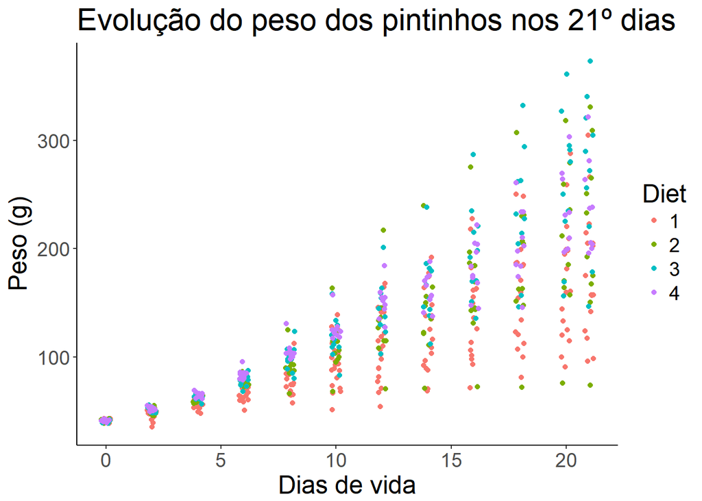

```r
data.plot
```

Aqui é apresentado a distribuição do peso dos pintinhos ao final dos 21 dias, de acordo com a dieta.

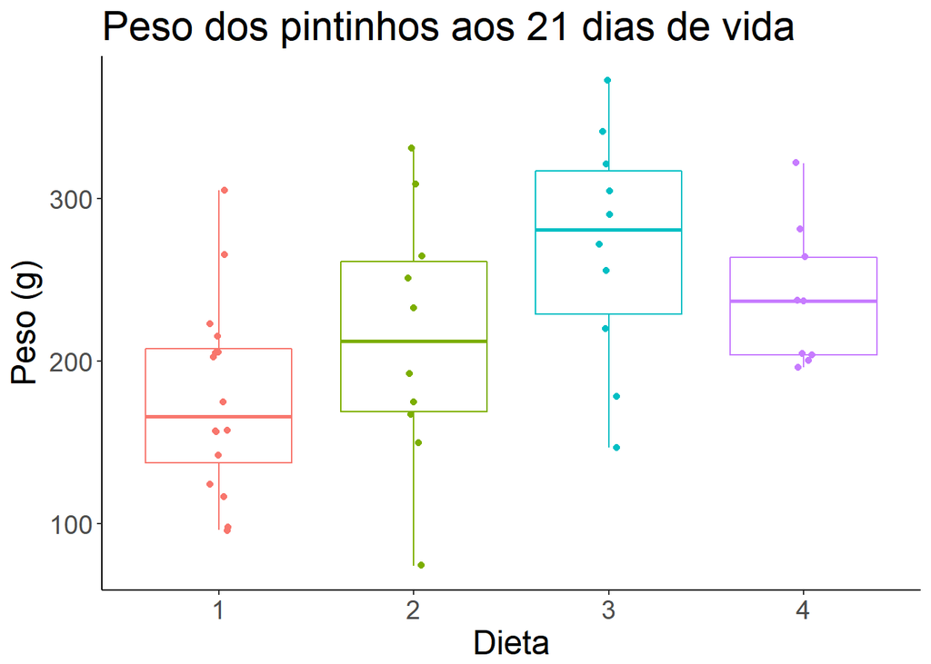

```r
time_21.plot
```

# Descriptive Statistics

Quando resumo da evolução do peso agrupando de acordo com os dias de vida, observamos como a variância aumenta com os dias. Podemos ver, com isso, a grande influência das dietas sobre o peso dos pintinhos.

```r
print.data.frame(weight_by_time)
```

```
##    Time weight_mean weight_sd weight_min weight_max
## 1     0    41.06000  1.132272         39         43
## 2     2    49.22000  3.688316         35         55
## 3     4    59.95918  4.495179         48         69
## 4     6    74.30612  9.012038         51         96
## 5     8    91.24490 16.239780         57        131
## 6    10   107.83673 23.987277         51        163
## 7    12   129.24490 34.119600         54        217
## 8    14   143.81250 38.300412         68        240
## 9    16   168.08511 46.904079         71        287
## 10   18   190.19149 57.394757         72        332
## 11   20   209.71739 66.511708         76        361
## 12   21   218.68889 71.510273         74        373
```

Quando olhamos o resumo do peso final dos pintinhos pelas 4 dietas, fica mais claro a diferença entre os resultados médios de cada dieta. Entretanto, ainda podemos ver um grande variabilidade nos resultados das dietas. A que se mostra mais consistente é a dieta “4”, apresentando um desvio médio de 43.3 gramas.

```r
print.data.frame(weight_21days_by_diet)
```

```
##   Diet weight_mean weight_sd weight_min weight_max
## 1    1    177.7500  58.70207         96        305
## 2    2    214.7000  78.13813         74        331
## 3    3    270.3000  71.62254        147        373
## 4    4    238.5556  43.34775        196        322
```

Por fim, para evidenciar a diferença entre o comportamento das dietas ao longo dos 21 dias, foi desenhado o gráfico abaixo de acordo com as médias para cada dia e dieta.

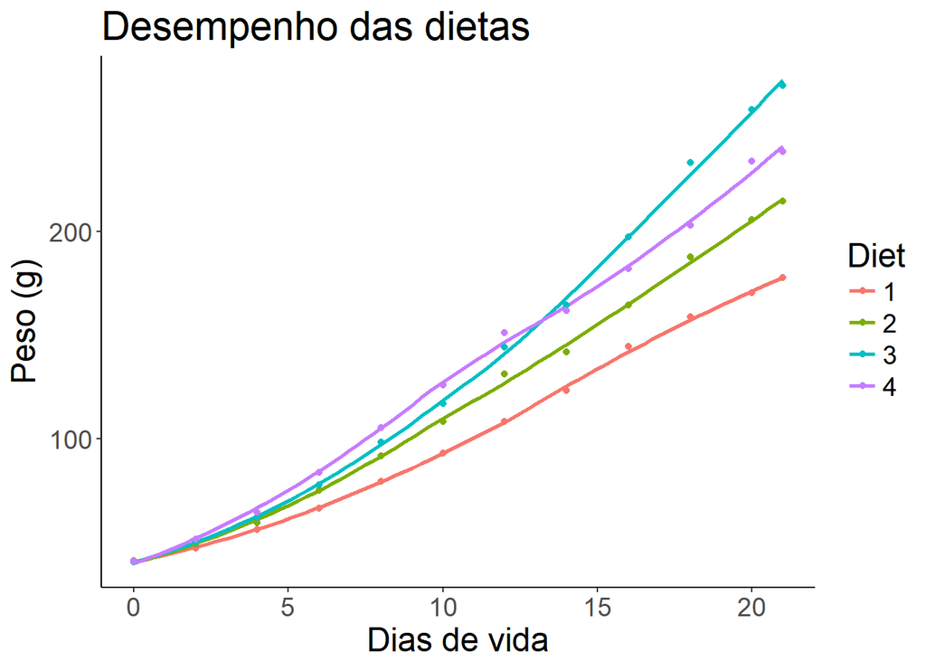

```r
weight_time_diet.plot
```